# PSTAT 131 HW 1

Jay Shreedhar

2022-04-02

Descriptive: We choose a model to best visually emphasize a trend in data, such as a line of best fit on a scatterplot.  
Inferential: We choose a model that best allows us to test hypotheses, state a relationship between the outcome and predictors, and determine which features of the model/data are significant.  
Predictive: We choose a model that allows us to determine which combination of features (predictors, etc.) fits the outcome best so that we can predict *Y* with minimum reducible error.

**5.**

Mechanistic: Assume a parametric form for *f*. This will NOT match the true unknown *f*. We can add parameters for more flexibility, but adding too many leads to overfitting. It is oversensitive to random noise in the training data, so with a new dataset it will not do well.  
Empirically-driven: No assumptions about *f*. We require a larger number of observations. It is much more flexible by default, which means overfitting is easy.  
These model types differ in that mechanistic models use a model to predict what will occur, while empirically-driven models use what has already occurred to build a model. They are similar in that both are susceptible to overfitting, meaning that their accuracy drops when using a dataset other than the training dataset.  
Generally, mechanistic models are easier to understand, as I’m more familiar with those from PSTAT 126.

**6.** The first question is predictive, while the second is inferential. This is because the first question uses data to predict *Y* (likelihood of voting in favor, in this case), while the second question attempts to test a theory of how *Y* would change given an additional predictor.  
**Exploratory Data Analysis**  
**Exercise 1:**

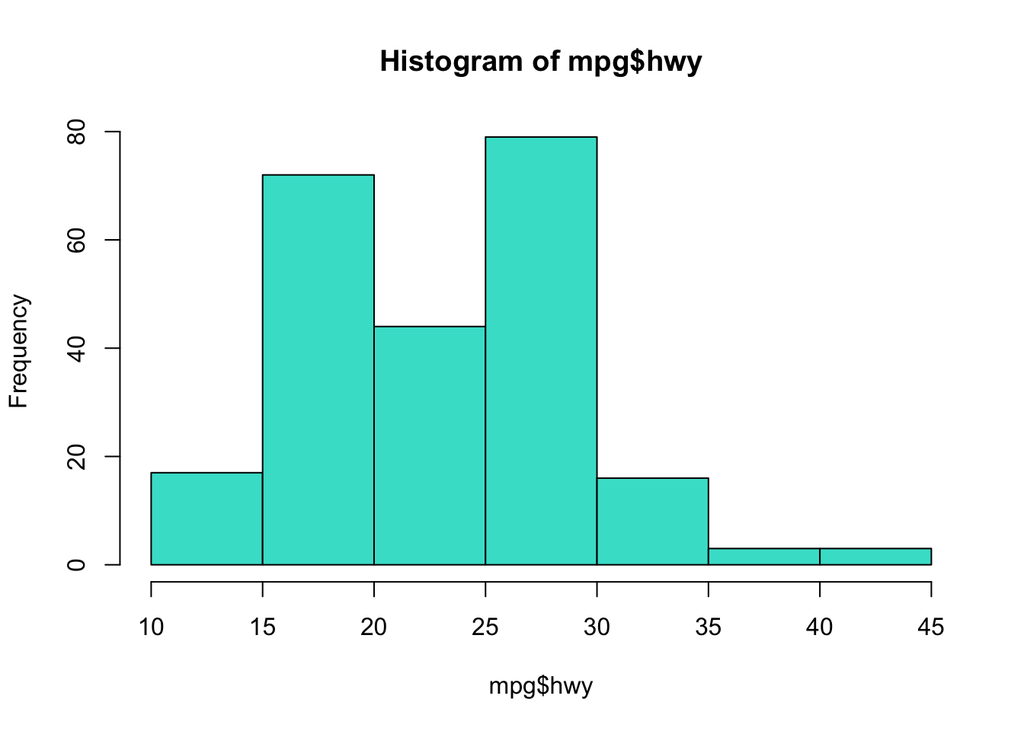

```r
library(tidyverse)
library(tidymodels)
library(ggplot2)
data(mpg)
hist(mpg$hwy, col="turquoise")
```

**Exercise 2:**

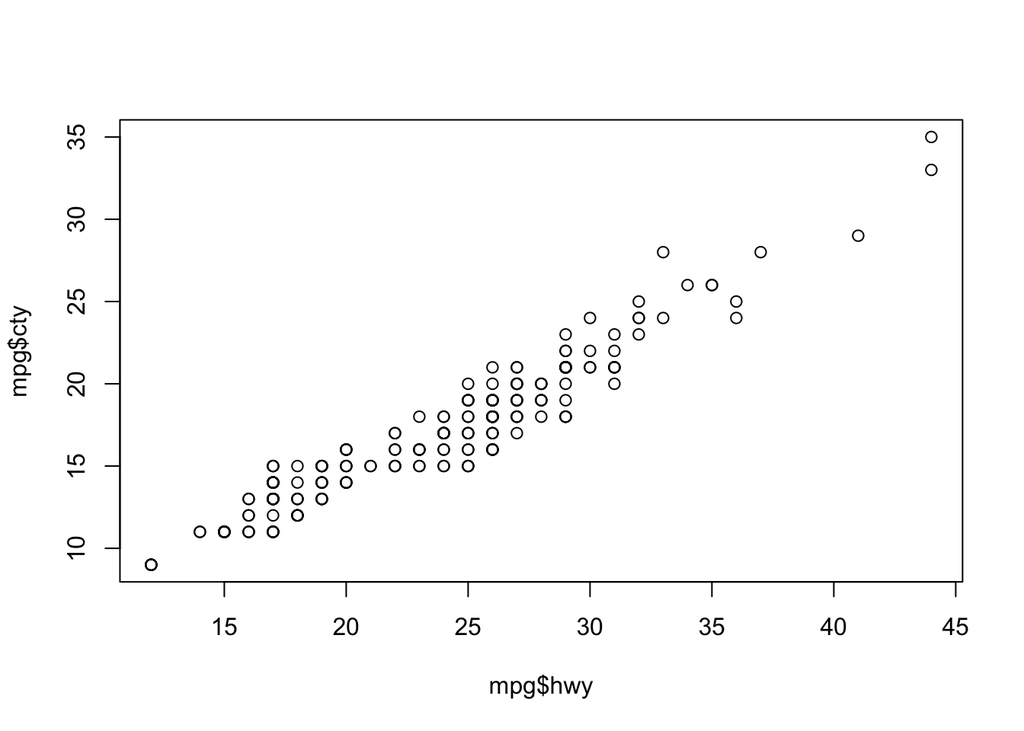

```r
plot(mpg$hwy, mpg$cty)
```

The two variables seem to closely follow a line. There is probably a relationship between hwy and cty, and this logically makes sense - highway mpg and city mpg would probably increase at the same rate, as a vehicle’s overall fuel economy would be better.

**Exercise 3:**

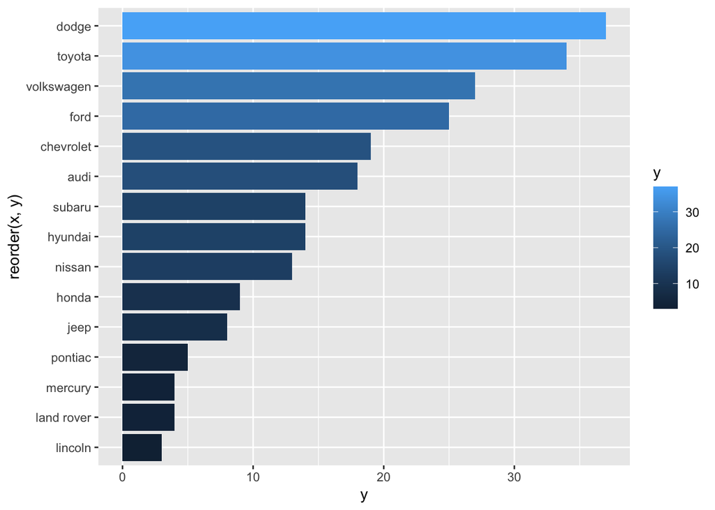

```r
library(RColorBrewer)
counts <- table(mpg$manufacturer)
x <- names(counts)
y <- as.numeric(counts)
df <- data.frame(x, y)
df <- arrange(df, y)
ggplot(df, aes(x=reorder(x,y), y, fill = y)) + geom_col() + coord_flip()
```

Dodge produced the most cars, while Lincoln produced the least.

**Exercise 4:**

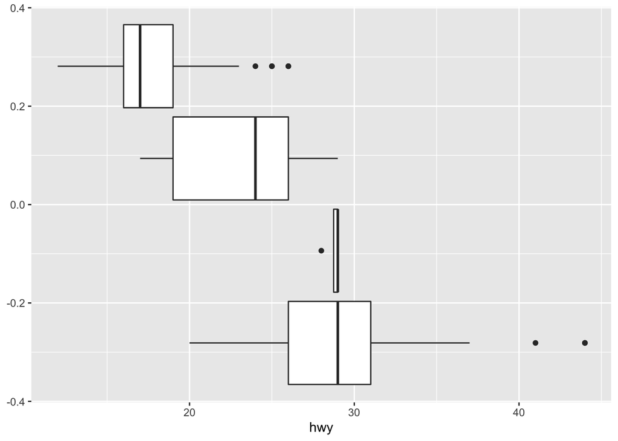

```r
bp <- ggplot(mpg, aes(group=cyl, x=hwy)) + geom_boxplot()
bp
```

**Exercise 5:**

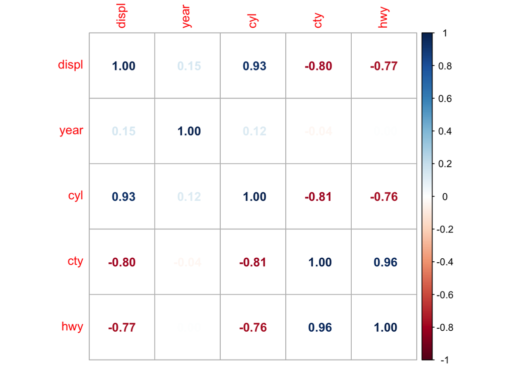

```r
library(corrplot)
dat <- mpg %>%
  select(-manufacturer, -model, -trans, -drv, -fl, -class)
X <- cor(dat)
corrplot(X, method = "number")
```

Number of cylinders and engine displacement, as well as highway mpg and city mpg, are positively correlated. City mpg and engine displacement; number of cylinders and highway mpg; and number of cylinders and city mpg are all negatively correlated. These relationships generally make sense, although I’m confused about city mpg and engine displacement.